# 4_task

V.S. Romantseva

18 марта 2018 г

Цель: исследовать набор данных Carseats с помощью линейной регрессионной модели. Задействовав все возможные регрессоры, сделать вывод о пригодности модели для прогноза. Сравнить с методом k ближайших соседей по MSE на тестовой выборке.

```
## 'data.frame':    400 obs. of  5 variables:
##  $ Sales      : num  9.5 11.22 10.06 7.4 4.15 ...
##  $ Advertising: num  11 16 10 4 3 13 0 15 0 0 ...
##  $ Price      : num  120 83 80 97 128 72 108 120 124 124 ...
##  $ ShelveLoc  : Factor w/ 3 levels "Bad","Good","Medium": 1 2 3 3 1 1 3 2 3 3 ...
##  $ US         : Factor w/ 2 levels "No","Yes": 2 2 2 2 1 2 1 2 1 2 ...
```

# Переменные

Sales - продажи детских автокресел в тысячах.

Prices - цена на каждое из автокресел.

Advertising - бюджет компаний на рекламу.

US - фактор, принимающий значения Yes, No, показывающий находится ли магазин в США или нет.

ShelveLoc - Фактор с уровнями Bad, Good и Medium, показывающий качество местоположения стеллажа для сидений автомобиля на каждом сайте

# Графики

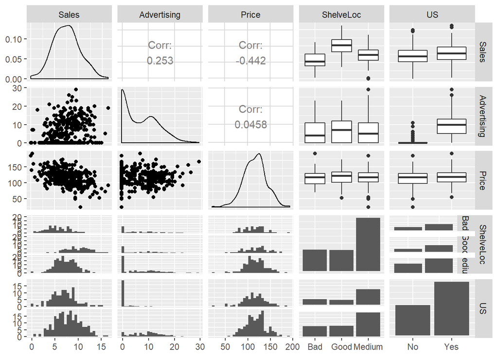

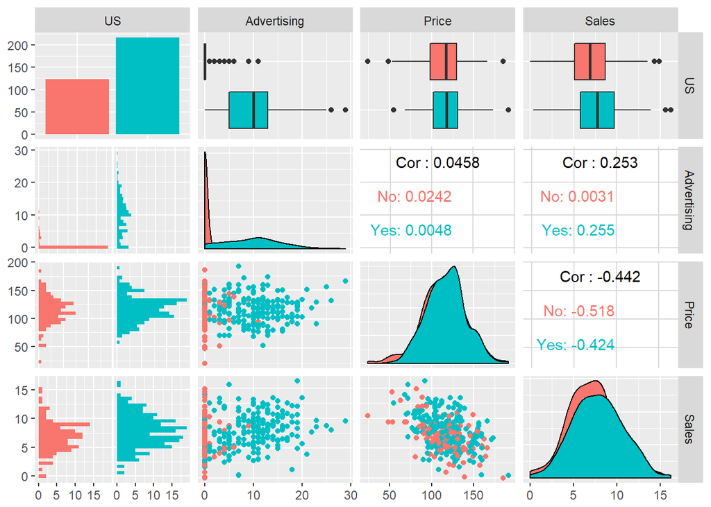

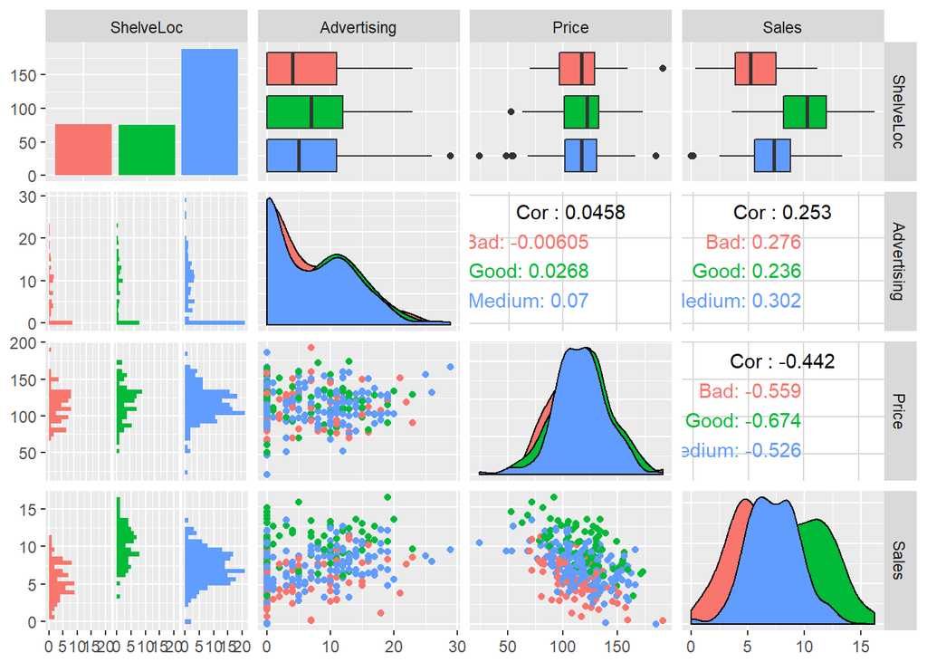

# Модели

```
##
## Call:
## lm(formula = Sales ~ . + Price:US + Price:ShelveLoc + Advertising:US +
##     Advertising:ShelveLoc, data = df.train)
##
## Residuals:
##     Min      1Q  Median      3Q     Max
## -5.6422 -1.1197  0.0208  1.1897  4.2575
##
## Coefficients:
##                              Estimate Std. Error t value Pr(>|t|)
## (Intercept)                 11.720192   1.290633   9.081  < 2e-16 ***
## Advertising                  0.146973   0.102358   1.436    0.152
## Price                       -0.059931   0.011093  -5.403 1.26e-07 ***
## ShelveLocGood                6.167308   1.487538   4.146 4.31e-05 ***
## ShelveLocMedium              1.215759   1.284506   0.946    0.345
## USYes                       -0.465596   1.035049  -0.450    0.653
## Price:USYes                  0.003385   0.008618   0.393    0.695
## Price:ShelveLocGood         -0.011077   0.012360  -0.896    0.371
## Price:ShelveLocMedium        0.004788   0.010865   0.441    0.660
## Advertising:USYes           -0.040611   0.101152  -0.401    0.688
## Advertising:ShelveLocGood   -0.002668   0.046298  -0.058    0.954
## Advertising:ShelveLocMedium  0.014483   0.038734   0.374    0.709
## ---
## Signif. codes:  0 '***' 0.001 '**' 0.01 '*' 0.05 '.' 0.1 ' ' 1
##
## Residual standard error: 1.828 on 328 degrees of freedom
## Multiple R-squared:  0.6007, Adjusted R-squared:  0.5873
## F-statistic: 44.85 on 11 and 328 DF,  p-value: < 2.2e-16
```

Убираем Advertising:ShelveLoc, т.к. коэффициенты при преременных являются наиболее незначимыми.

```
##
## Call:
## lm(formula = Sales ~ . + Price:US + Price:ShelveLoc + Advertising:US,
##     data = df.train)
##
## Residuals:
##     Min      1Q  Median      3Q     Max
## -5.7319 -1.1345  0.0278  1.1514  4.2329
##
## Coefficients:
##                        Estimate Std. Error t value Pr(>|t|)
## (Intercept)           11.676482   1.280035   9.122  < 2e-16 ***
## Advertising            0.153562   0.098616   1.557    0.120
## Price                 -0.059969   0.011056  -5.424 1.13e-07 ***
## ShelveLocGood          6.150651   1.459339   4.215 3.23e-05 ***
## ShelveLocMedium        1.288797   1.264989   1.019    0.309
## USYes                 -0.463714   1.030620  -0.450    0.653
## Price:USYes            0.003433   0.008575   0.400    0.689
## Price:ShelveLocGood   -0.011137   0.012325  -0.904    0.367
## Price:ShelveLocMedium  0.004936   0.010832   0.456    0.649
## Advertising:USYes     -0.039943   0.100864  -0.396    0.692
## ---
## Signif. codes:  0 '***' 0.001 '**' 0.01 '*' 0.05 '.' 0.1 ' ' 1
##
## Residual standard error: 1.824 on 330 degrees of freedom
## Multiple R-squared:  0.6004, Adjusted R-squared:  0.5895
## F-statistic: 55.08 on 9 and 330 DF,  p-value: < 2.2e-16
```

Убираем Advertising:US, т.к. коэффициент является наиболее незначимыми. В целом модель не стала лучше, перейде к следущему исключению регрессогов.

```
##
## Call:
## lm(formula = Sales ~ . + Price:US + Price:ShelveLoc, data = df.train)
##
## Residuals:
##     Min      1Q  Median      3Q     Max
## -5.7511 -1.1188  0.0228  1.1676  4.2457
##
## Coefficients:
##                        Estimate Std. Error t value Pr(>|t|)
## (Intercept)           11.695213   1.277530   9.155  < 2e-16 ***
## Advertising            0.115372   0.020593   5.602 4.45e-08 ***
## Price                 -0.059921   0.011041  -5.427 1.11e-07 ***
## ShelveLocGood          6.143105   1.457354   4.215 3.22e-05 ***
## ShelveLocMedium        1.279347   1.263152   1.013    0.312
## USYes                 -0.493549   1.026553  -0.481    0.631
## Price:USYes            0.003372   0.008563   0.394    0.694
## Price:ShelveLocGood   -0.011158   0.012309  -0.906    0.365
## Price:ShelveLocMedium  0.004982   0.010817   0.461    0.645
## ---
## Signif. codes:  0 '***' 0.001 '**' 0.01 '*' 0.05 '.' 0.1 ' ' 1
##
## Residual standard error: 1.821 on 331 degrees of freedom
## Multiple R-squared:  0.6002, Adjusted R-squared:  0.5905
## F-statistic:  62.1 on 8 and 331 DF,  p-value: < 2.2e-16
```

```
##
## Call:
## lm(formula = Sales ~ . + Price:ShelveLoc, data = df.train)
##
## Residuals:
##     Min      1Q  Median      3Q     Max
## -5.7622 -1.1204  0.0037  1.1410  4.2353
##
## Coefficients:
##                        Estimate Std. Error t value Pr(>|t|)
## (Intercept)           11.409223   1.049742  10.869  < 2e-16 ***
## Advertising            0.115444   0.020566   5.613 4.20e-08 ***
## Price                 -0.057411   0.009003  -6.377 6.06e-10 ***
## ShelveLocGood          6.202257   1.447748   4.284 2.41e-05 ***
## ShelveLocMedium        1.363224   1.243483   1.096    0.274
## USYes                 -0.104705   0.280710  -0.373    0.709
## Price:ShelveLocGood   -0.011690   0.012219  -0.957    0.339
## Price:ShelveLocMedium  0.004243   0.010640   0.399    0.690
## ---
## Signif. codes:  0 '***' 0.001 '**' 0.01 '*' 0.05 '.' 0.1 ' ' 1
##
## Residual standard error: 1.819 on 332 degrees of freedom
## Multiple R-squared:    0.6,  Adjusted R-squared:  0.5915
## F-statistic: 71.14 on 7 and 332 DF,  p-value: < 2.2e-16
```

Были убраны переменные Price:US и Price:ShelveLoc, т.к. они не влияют на Sales.

```
##
## Call:
## lm(formula = Sales ~ ., data = df.train)
##
## Residuals:
##    Min     1Q Median     3Q    Max
## -5.770 -1.139  0.022  1.178  4.130
##
## Coefficients:
##                  Estimate Std. Error t value Pr(>|t|)
## (Intercept)     11.482624   0.528083  21.744  < 2e-16 ***
## Advertising      0.115617   0.020553   5.625 3.92e-08 ***
## Price           -0.058094   0.004157 -13.974  < 2e-16 ***
## ShelveLocGood    4.821478   0.297039  16.232  < 2e-16 ***
## ShelveLocMedium  1.858488   0.248370   7.483 6.51e-13 ***
## USYes           -0.099404   0.280565  -0.354    0.723
## ---
## Signif. codes:  0 '***' 0.001 '**' 0.01 '*' 0.05 '.' 0.1 ' ' 1
##
## Residual standard error: 1.82 on 334 degrees of freedom
## Multiple R-squared:  0.5969, Adjusted R-squared:  0.5909
## F-statistic: 98.92 on 5 and 334 DF,  p-value: < 2.2e-16
```

Переменная US является незначимой, построим уравнение без нее.

```
##
## Call:
## lm(formula = Sales ~ Advertising + Price + ShelveLoc, data = df.train)
##
## Residuals:
##    Min     1Q Median     3Q    Max
## -5.745 -1.144  0.006  1.187  4.157
##
## Coefficients:
##                  Estimate Std. Error t value Pr(>|t|)
## (Intercept)     11.453558   0.520990  21.984  < 2e-16 ***
## Advertising      0.110684   0.015099   7.331 1.73e-12 ***
## Price           -0.058154   0.004148 -14.018  < 2e-16 ***
## ShelveLocGood    4.821899   0.296649  16.255  < 2e-16 ***
## ShelveLocMedium  1.865719   0.247206   7.547 4.24e-13 ***
## ---
## Signif. codes:  0 '***' 0.001 '**' 0.01 '*' 0.05 '.' 0.1 ' ' 1
##
## Residual standard error: 1.818 on 335 degrees of freedom
## Multiple R-squared:  0.5968, Adjusted R-squared:  0.592
## F-statistic: 123.9 on 4 and 335 DF,  p-value: < 2.2e-16
```

В полученной модели 6 все коэффициенты являются значимыми. Далее работать будем с ней.